# Prueba Convocatoria Analista de Inversión

Juan Fernando Henao Duque

# Lectura de los datos

Se contruyo la base de datos con tres campos: fecha, tasa representativa del mercado y precio del barril del petróleo tipo brent, dado que este desde 2008 es el precio de referencia para la compañia Ecopetrol. La base de datos se aumenta utilizando variables indicadoras para los días de la semana, los meses del año. La fuente de información para la serie del Brent es a través de U.S. Energy Information Administration (EIA), y para la tasa representativa del mercado (TRM) es el Banco de la República (BanRep) cargamos estas series a las cuales le asignaremos el nombre de Base.

```r
#install.packages("quantmod")
#install.packages("dplyr")
#library(quantmod)
#library(gplots)
#library(dplyr)
getwd()
```

```
[1] "/Users/jfhenaoduque/Google Drive/SURA"
```

```r
setwd("/Users/jfhenaoduque/Google Drive/SURA")
```

```r
# Base de datos
Base <- read.csv("/Users/jfhenaoduque/Google Drive/SURA/BDPunto1.csv", sep=";", dec=".")
# Importamos los datos
Base<-na.omit(Base)
```

En el código anterior, se entenderá que **Base** es el nombre que tomará nuestra serie. Como al momento de cargar los datos, éstos se verán como una hoja plana de información, es decir, el programa leerá los datos, pero asumirá que es una impresión, no manipulable; se contrarresta este inconveniente introducimendo el comando **attach** que nos ayudará a seccionar la información, dándole la opción al programa de transformar la información como si fuera una serie cargada en Excel, brindándonos completa manipulación.:

```r
attach(Base)
```

Otro problema identificable en R es el hecho que por defecto los resultados del programa siempre serán vistos en formato de notación cientifica cuando los datos tienen muchos decimales. Entonces, para modificar los resultados, a fin de obtener el resultado con los decimales completos usamos la función:

```r
options(scipen = 999)
```

##### *NOTA*

**Sobre la descarga de los datos: Inicialmente intente hacer la descarga del Brent por Yahoo Finance con frecuencia diaria del tickey BZ=F pero este no fue posible, ya que solo me generaba los últimos 20 datos, para testear si era algo del código o error mío (capa 8) lo probe con el del WTI que tiene etiqueta CL=F y la descarga si se efectuó. No obstante, dado que la economía colombiana tiene como precio de referencia desde 2008 el Brent, realice su descarga en EIA que recoge las cifras arrojadas por Thomson Reuters**

Convertimos la serie diaria en mensual

```r
BaseMensual<-Base[-c(1:20,22:40,42:60,62:82,84:103,105:123,125:146,148:167,169:188,190:211,213:230,232:252,
                     254:272,274:291,293:313,315:334,336:354,356:376,378:398,400:419,421:440,442:461,463:482,484:504,
                     506:523,525:542,544:564,566:585,587:605,607:628,630:649,651:671,673:692,694:713,715:734,736:756,
                     758:776,778:795,797:818,820:838,840:859,861:881,883:901,903:924,926:945,947:966,968:987,989:1008,
                     1010:1028,1030:1048,1050:1070,1072:1090,1092:1112,1114:1133,1135:1154,1156:1177,1179:1196,1198:1219,1221:1240,1242:1260,
                     1262:1281,1283:1300,1302:1320,1322:1342,1344:1364,1366:1384,1386:1406,1408:1428,1430:1448,1450:1471,1473:1491,1493:1512,
                     1514:1534,1536:1553,1555:1574,1576:1595,1597:1617,1619:1638,1640:1660,1662:1681,1683:1702,1704:1725,1727:1744,1746:1766,
                     1768:1786,1788:1806,1808:1828,1830:1849,1851:1869,1871:1890,1893:1912,1914:1935,1937:1956,1958:1979,1981:2000,2002:2022,
                     2024:2042,2044:2062,2064:2084,2086:2104,2106:2126,2128:2148,2150:2169,2171:2192,2194:2214,2216:2235,2237:2257,2259:2278,
                     2280:2299,2301:2319,2321:2342,2344:2361,2363:2384,2386:2406,2408:2427,2429:2450,2452:2471,2473:2493,2495:2515,2517:2535,
                     2537:2557,2559:2577,2579:2598,2600:2619,2621:2641,2643:2662,2664:2684,2686:2707,2709:2727,2729:2749,2751:2772,2774:2790,
                     2792:2812,2814:2832,2834:2853,2855:2874,2876:2896,2898:2916,2918:2939,2941:2961,2963:2982,2984:3005,3007:3026,3028:3047,
                     3049:3069,3071:3089,3091:3111,3113:3132,3134:3152,3154:3174,3176:3197,3199:3218,3220:3240,3242:3260),]
```

Convertimos la serie anual

```r
BaseAnual<-Base[-c(1:252,254:504,506:756,758:1008,1010:1260,1262:1512,1514:1766,1768:2022,2024:2278,2280:2535,2537:2790,2792:3047,3049:3260),]
```

Realizamos los gráficos de la TRM y el precio del petróleo Brent en sus diferentes frecuencias:

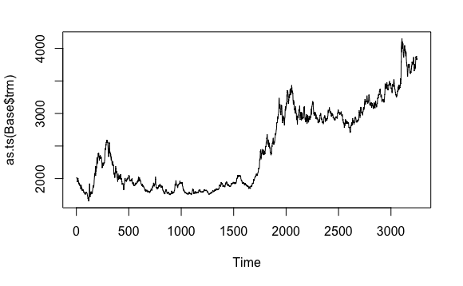

```r
plot(as.ts(Base$trm))
```

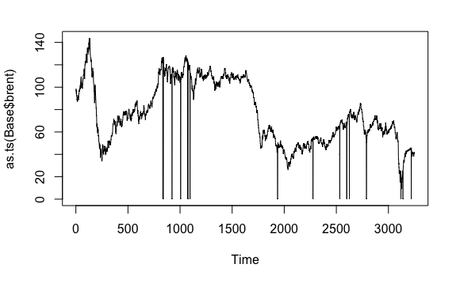

```r
plot(as.ts(Base$brent))
```

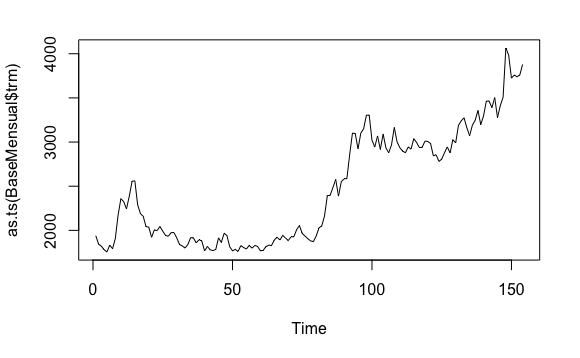

```r
plot(as.ts(BaseMensual$trm))
```

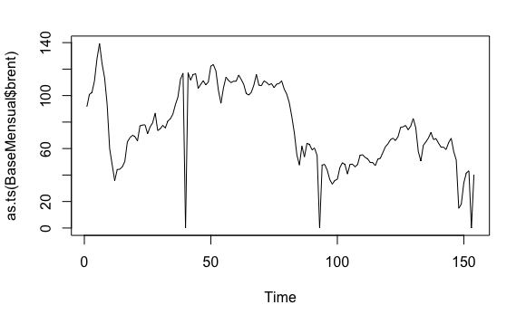

```r
plot(as.ts(BaseMensual$brent))
```

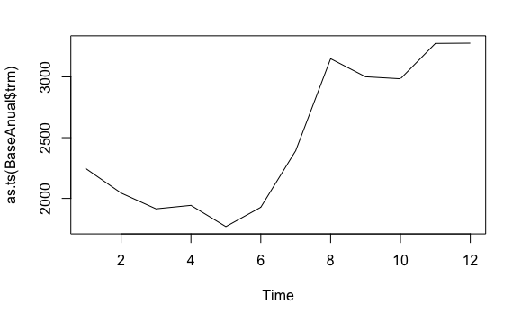

```r
plot(as.ts(BaseAnual$trm))
```

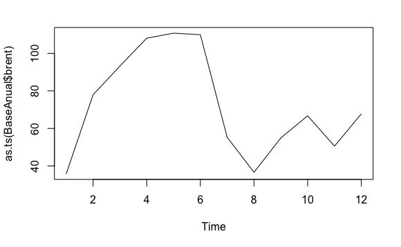

```r
plot(as.ts(BaseAnual$brent))
```